# 2212063

ALEEMUDDIN MD

2023-04-20

## Introduction

#### We have access to a data set that contains instances of criminal event cases that took place in Dallas, Texas, USA, during 2016, as well as details about the officer in question, their location, race, time, and other factors.We will make an effort to generate facts and arguments based on the data we have gathered in order to aid in the improvement of the legal system in Dallas, Texas. Then, we shall present these arguments and the arguments’ supporting data.The data includes details on 2384 occurrences and 47 factors. Infractions between January 1 and December 31, 2016, were reported as 2382.

```r
# Loaded the libraries
library(dplyr)
library(tidyverse)
library(ggplot2)
library(leaflet)
library(plotly)
library(hrbrthemes)
library(ggcorrplot)
library(RColorBrewer)
```

```r
#Loading the dataset
DateTime<- read.csv("C:/Users/MD ALEEMUDDIN/Desktop/ESSEX PROJECTS/MA304/37-00049_UOF-P_2016_prepped.csv")

#Removing the 1 row from the dataset to build clean Data set
DateTime <- DateTime[-1,]
```

### Converting the time and Date to valid format

```r
#Date time
DateTime$INCIDENT_DATE <- as.Date(DateTime$INCIDENT_DATE, format = "%m/%d/%Y")
DateTime$INCIDENT_DATE <- gsub("00","20",DateTime$INCIDENT_DATE)
DateTime$INCIDENT_DATE <- as.Date(DateTime$INCIDENT_DATE, format = "%Y-%m-%d")
DateTime$INCIDENT_TIME <- format(strptime(DateTime$INCIDENT_TIME, "%I:%M:%S %p"), "%H:%M:%S")
DateTime$INCIDENT_MONTH <- months(as.Date(DateTime$INCIDENT_DATE))
DateTime$INC_MONTH <-format(DateTime$INCIDENT_DATE,"%m")
```

## Subject Gender vs Subject Race

#### We will demonstrate the relationship between Subject Race and Subject Gender in the line of code below.We can see from this that the majority of men are black.

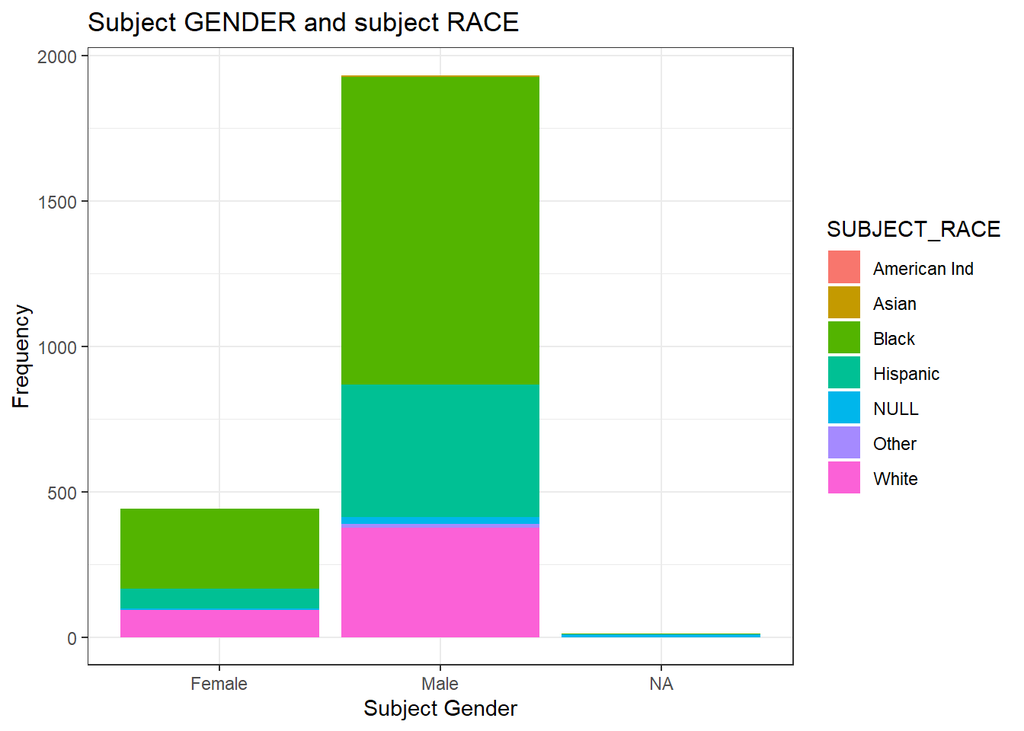

```r
#Barplot for subject gender and subject race
barPlot<- DateTime %>%group_by(SUBJECT_GENDER,SUBJECT_RACE) %>%
  summarize(count=n())
  ggplot(DateTime,aes(x =factor(SUBJECT_GENDER,level=c("Female","Male")),fill=SUBJECT_RACE))+
  geom_bar()+
  theme_bw()+
  labs(title = "Subject GENDER and subject RACE",
       x = "Subject Gender",
       y = "Frequency")
```